# R Notebook

# Series de tiempo: comparativa entre un modelo ARIMA y prophet

En el siguiente trabajo se abordará la modelización y la predicción de la serie temporal de pasajeros del subte de Buenos Aires utilizando ARIMA y prophet.

### Introducción

En primer lugar, importamos las librerías a utilizar:

```r
rm(list=ls())

require(dplyr)
require(ggplot2)
require(ggfortify)
require(tsibble)
require(lubridate)
require(prophet)
require(forecast)
require(broom)
require(tseries)
require(fable)
```

### Análisis exploratorio

Importamos los datasets con los que se va a trabajar:

```r
df_abc <- read.csv("./datasets/202208_PAX15min-ABC.csv", sep=";")
df_deh <- read.csv("./datasets/202208_PAX15min-DEH.csv", sep=";")

df <- bind_rows(df_abc, df_deh)
rm(df_abc, df_deh)
print(colnames(df))
```

```
##  [1] "FECHA"           "DESDE"           "HASTA"           "LINEA"
##  [5] "MOLINETE"        "ESTACION"        "pax_pagos"       "pax_pases_pagos"
##  [9] "pax_franq"       "pax_TOTAL"
```

Agrupamos la información a nivel estación/horario y convertimos a formato fecha/hora:

```r
df_linea <- df %>%
  group_by(FECHA,DESDE,HASTA,LINEA,ESTACION) %>%
  summarize(pasajeros = sum(pax_TOTAL)) %>%
  mutate(ts = dmy_hms(paste0(FECHA," " ,DESDE)))%>%
  ungroup() %>%
  select(-c(FECHA, DESDE, HASTA))
```

Agrupamos por linea y observamos la cantidad de pasajeros para cada una de ellas:

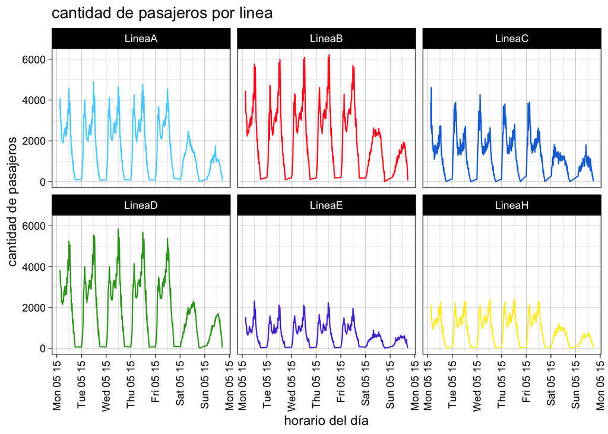

```r
df_linea %>%
  filter(ts >= "2022-08-01 05:15:00" & ts <= "2022-08-07 23:15:00") %>%
  group_by(LINEA, ts) %>%
  summarise(pasajeros = sum(pasajeros)) %>%
  ggplot() +
  aes(x = ts, y = pasajeros, fill = LINEA, colour = LINEA, group = LINEA) +
  geom_line(size = 0.5) +
  scale_fill_manual(values = c(LineaA = "#5CD2FB", LineaB = "#FD2929", LineaC = "#1872D6", LineaD = "#39A029", LineaE = "#583FD2", LineaH = "#FFEC3B")) +
  scale_color_manual(values = c(LineaA = "#5CD2FB", LineaB = "#FD2929", LineaC = "#1872D6", LineaD = "#39A029", LineaE = "#583FD2", LineaH = "#FFEC3B")) +
  labs(x = "horario del día", y = "cantidad de pasajeros", title = "cantidad de pasajeros por linea") +
  theme_linedraw() +
  theme(legend.position = "none") +
  facet_wrap(vars(LINEA)) +
  scale_x_datetime(breaks= seq(min(df_linea$ts), max(df_linea$ts), by = "24 hour"), date_labels = "%a %H %M") +
  theme(axis.text.x = element_text(angle = 90, vjust = 0.5, hjust=1))
```

Para el análisis, nos vamos a quedar con la información de la estación palermo de la linea D y vamos a trabajar con los siguientes períodos:

Train: 1/08/2022 al 21/08/2022 Test: 22/08/2022 al 28/08/2022

```r
feriados = as.Date(c("2022-08-15"))

df_analisis <- df_linea %>%
  filter(ts > "2022-08-01" & ts < "2022-08-29" & ESTACION == "Palermo") %>%
  mutate(ts = floor_date(ts, unit = 'hour')) %>%
  group_by(ts) %>%
  summarise(y = sum(pasajeros)) %>%
  rename(ds = ts) %>%
  mutate(dia_semana = as.character(wday(ds, label=TRUE)),
         hora = as.character(hour(ds)),
         time_index = row_number(),
         log_y = log(y),
         feriado = if_else(as.Date(floor_date(ds, unit = 'day')) %in% feriados, TRUE, FALSE))

df_train <- df_analisis %>%
  filter(ds < "2022-08-22")

df_test <- df_analisis %>%
  filter(ds > "2022-08-22")
```

Observo la serie:

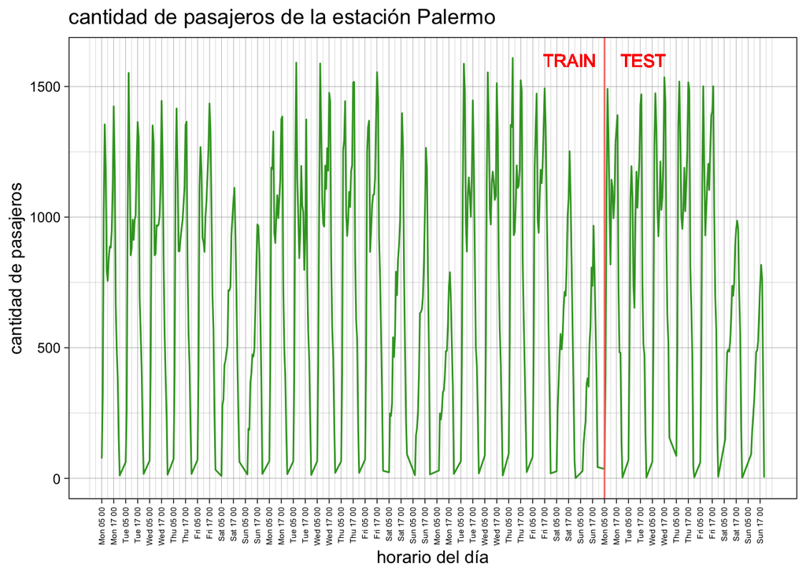

```r
df_analisis %>%
  ggplot(aes(x = ds, y=y)) +
  geom_line(colour = "#39A029") +
  labs(x = "horario del día", y = "cantidad de pasajeros", title = "cantidad de pasajeros de la estación Palermo") +
  theme_linedraw() +
  theme(legend.position = "none") +
  scale_x_datetime(breaks= seq(min(df_analisis$ds), max(df_analisis$ds), by = "12 hour"), date_labels = "%a %H %M") +
  theme(axis.text.x = element_text(angle = 90, vjust = 0.5, hjust=1, size = 5)) +
  geom_vline(aes(xintercept=min(df_test$ds), color='red')) +
  geom_text(aes(x=min(df_test$ds) , label="TRAIN     TEST", y=1600), colour="red", angle=0)
```

### ARIMA

En primer lugar, se va a armar una regresión lineal con la tendencia y las variables estacionales. Luego, utilizará ARIMA para intentar captar cierto componente autoregresivo en la serie.

```r
reg = lm(log_y ~ dia_semana + hora + feriado + time_index, data = df_train)
summary(reg)
```

```
##
## Call:
## lm(formula = log_y ~ dia_semana + hora + feriado + time_index,
##     data = df_train)
##
## Residuals:
##      Min       1Q   Median       3Q      Max
## -2.82811 -0.16866 -0.02623  0.20110  1.65410
##
## Coefficients:
##                 Estimate Std. Error t value Pr(>|t|)
## (Intercept)    0.9976059  0.4775135   2.089   0.0374 *
## dia_semanaMon -0.1532305  0.1022393  -1.499   0.1348
## dia_semanaSat -0.4237680  0.0866532  -4.890 1.52e-06 ***
## dia_semanaSun -1.1182848  0.0915869 -12.210  < 2e-16 ***
## dia_semanaThu -0.0629653  0.0866532  -0.727   0.4679
## dia_semanaTue -0.1247164  0.0875767  -1.424   0.1553
## dia_semanaWed -0.0793106  0.0870007  -0.912   0.3626
## hora10         5.7799597  0.4777731  12.098  < 2e-16 ***
## hora11         5.8284802  0.4777586  12.200  < 2e-16 ***
## hora12         5.9677984  0.4777442  12.492  < 2e-16 ***
## hora13         6.0246890  0.4777300  12.611  < 2e-16 ***
## hora14         6.0463735  0.4777159  12.657  < 2e-16 ***
## hora15         6.1156502  0.4777018  12.802  < 2e-16 ***
## hora16         6.2201380  0.4776879  13.021  < 2e-16 ***
## hora17         6.3911756  0.4776742  13.380  < 2e-16 ***
## hora18         6.4061548  0.4776605  13.412  < 2e-16 ***
## hora19         6.0347301  0.4776469  12.634  < 2e-16 ***
## hora20         5.6992351  0.4776335  11.932  < 2e-16 ***
## hora21         5.3826127  0.4776202  11.270  < 2e-16 ***
## hora22         4.2287720  0.4776070   8.854  < 2e-16 ***
## hora23         2.2146937  0.4815674   4.599 5.89e-06 ***
## hora5          3.1153992  0.4818186   6.466 3.28e-10 ***
## hora6          5.0079512  0.4818037  10.394  < 2e-16 ***
## hora7          5.3542155  0.4778172  11.206  < 2e-16 ***
## hora8          5.9451508  0.4778024  12.443  < 2e-16 ***
## hora9          5.9572075  0.4777877  12.468  < 2e-16 ***
## feriadoTRUE   -1.0840267  0.1454475  -7.453 6.85e-13 ***
## time_index     0.0003244  0.0002360   1.374   0.1702
## ---
## Signif. codes:  0 '***' 0.001 '**' 0.01 '*' 0.05 '.' 0.1 ' ' 1
##
## Residual standard error: 0.462 on 360 degrees of freedom
## Multiple R-squared:  0.8583, Adjusted R-squared:  0.8476
## F-statistic: 80.74 on 27 and 360 DF,  p-value: < 2.2e-16
```

Realizamos la predicción para train y para test:

```r
df_train$y_hat_log = predict(reg)
df_test$y_hat_log = predict(reg, newdata = df_test)
```

Calculo la exponencial de las predicciones para llevarlo a la escala real de la serie:

```r
df_train$y_hat = exp(df_train$y_hat_log)
df_test$y_hat = exp(df_test$y_hat_log)
```

Ploteo los valores de test y las predicciones de este primer modelo:

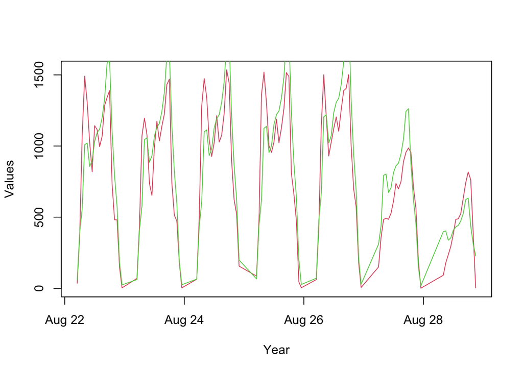

```r
plot(df_test$ds,                              # Draw first time series
     df_test$y,
     type = "l",
     col = 2,
     #ylim = c(- 15, 40),
     xlab = "Year",
     ylab = "Values")
lines(df_test$ds,                             # Draw second time series
      df_test$y_hat,
      type = "l",
      col = 3)
```

Calculamos los residuos:

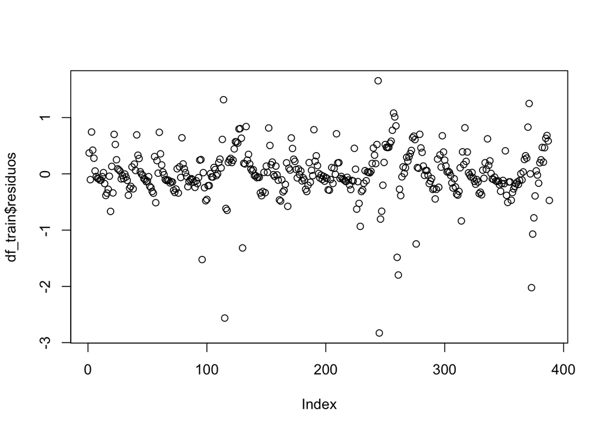

```r
df_train$residuos = reg$residuals
plot(df_train$residuos)
```

Probamos la estacionariedad de la serie con el test de dickey-fuller:

```r
adf.test(df_train$residuos)
```

```
##
##  Augmented Dickey-Fuller Test
##
## data:  df_train$residuos
## Dickey-Fuller = -8.0927, Lag order = 7, p-value = 0.01
## alternative hypothesis: stationary
```

Se observa que la serie es estacionaria. No sería necesario transformarla o diferenciarla.

Observamos la serie y los gráficos de la función de autocorrelación y la de autocorrelación parcial para ver qué valores de p y q debería tomar el modelo ARMA:

```
## Plot variable not specified, automatically selected `y = residuos`
```

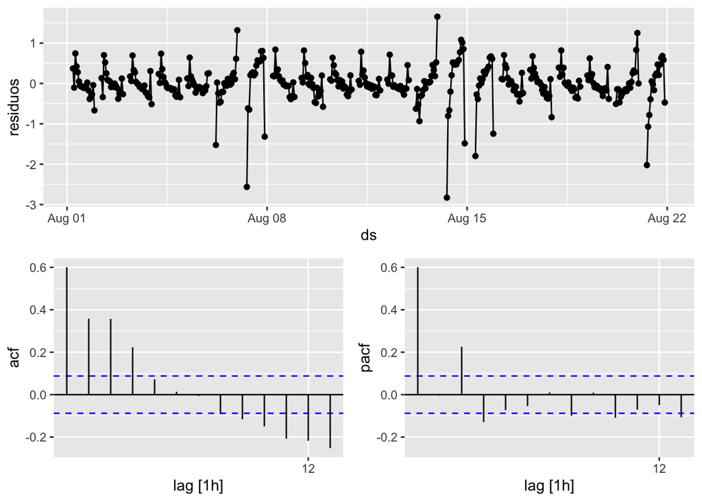

```r
library(feasts)

gg_tsdisplay(df_train %>% as_tsibble(index = ds) %>% fill_gaps() %>% select(residuos), plot_type='partial')
```

Utilizando la librería fable, probamos varios modelos ARIMA (incluso algunos que nos propone una exploración más exhaustiva) y nos quedamos con aquel que tenga el menor AIC:

```r
require(fable)

modelos = df_train %>% as_tsibble(index = ds) %>% fill_gaps() %>%
  model(arima200 = ARIMA(residuos ~ pdq(2,0,0)),
        arima001 = ARIMA(residuos ~ pdq(0,0,1)),
        arima201 = ARIMA(residuos ~ pdq(2,0,1)),
        stepwise = ARIMA(residuos),
        search = ARIMA(residuos, stepwise=FALSE))
glance(modelos) %>% arrange(AICc) %>% select(.model:BIC)
```

| .model | sigma2 | log_lik | AIC | AICc | BIC |
| --- | --- | --- | --- | --- | --- |
| arima200 | 0.1104781 | -176.0601 | 358.1203 | 358.1688 | 370.7521 |
| arima201 | 0.1097260 | -174.2636 | 358.5271 | 358.6491 | 379.5801 |
| arima001 | 0.1255207 | -198.6596 | 403.3192 | 403.3678 | 415.9510 |
| stepwise | 0.1249958 | -208.1991 | 422.3981 | 422.4468 | 435.0239 |
| search | 0.1245939 | -207.9805 | 425.9611 | 426.0833 | 447.0040 |

Analizo los residuos del arima:

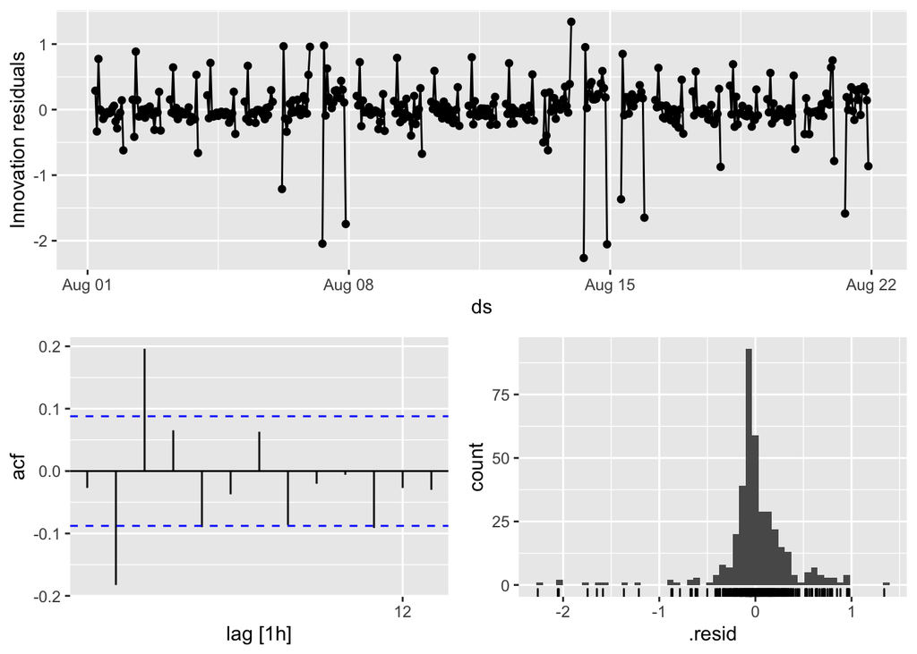

```r
modelos %>%
  select(arima200) %>%
  gg_tsresiduals()
```

Realizo el test de dickey-fuller sobre los residuos:

```r
residuos = as.data.frame(modelos %>%
  select(arima200) %>%
  residuals())

adf.test(residuos %>% filter(!is.na(.resid)) %>% select(.resid) %>% as.ts())
```

```
##
##  Augmented Dickey-Fuller Test
##
## data:  residuos %>% filter(!is.na(.resid)) %>% select(.resid) %>% as.ts()
## Dickey-Fuller = -8.0119, Lag order = 7, p-value = 0.01
## alternative hypothesis: stationary
```

Se observa que los residuos son estacionarios.

Realizo las predicciones sobre test:

```r
pred_train = modelos %>%
  select(arima200) %>% fitted()

pred_test = modelos %>%
  select(arima200) %>% forecast(h = "1 week")
```

sumo predicción del modelo anterior + arima tanto para train como para test.

```r
df_train = left_join(df_train, pred_train[c('ds', '.fitted')],
              by = 'ds')

df_test = left_join(df_test, pred_test[c('ds', '.mean')],
              by = 'ds')
```

Observamos la modelización del arima:

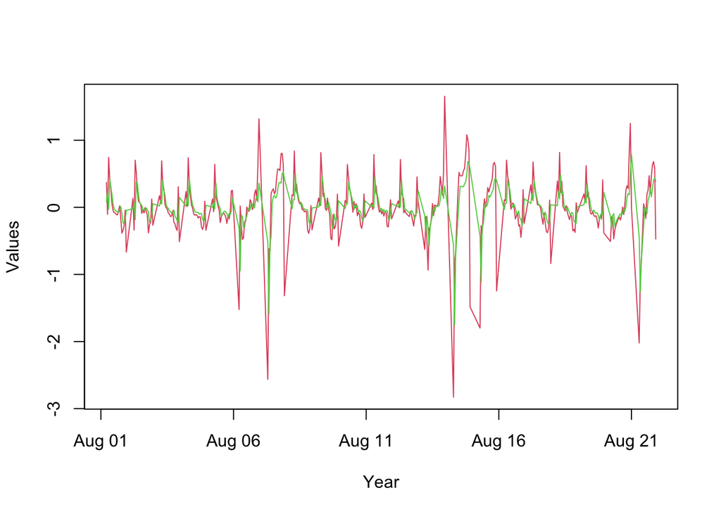

```r
plot(df_train$ds,                              # Draw first time series
     df_train$residuos,
     type = "l",
     col = 2,
     #ylim = c(- 15, 40),
     xlab = "Year",
     ylab = "Values")
lines(df_train$ds,                             # Draw second time series
      df_train$.fitted,
      type = "l",
      col = 3)
```

Sumamos los resultados del ARIMA a los del primer modelo y calculo la exponencial para llevarlo a la escala original de la serie:

```r
df_train = df_train %>%
  mutate(y_final_log = y_hat_log + .fitted,
         y_final = exp(y_final_log))

df_test = df_test %>%
  mutate(y_final_log = y_hat_log + .mean,
         y_final = exp(y_final_log))
```

Ploteo predicción vs valores reales:

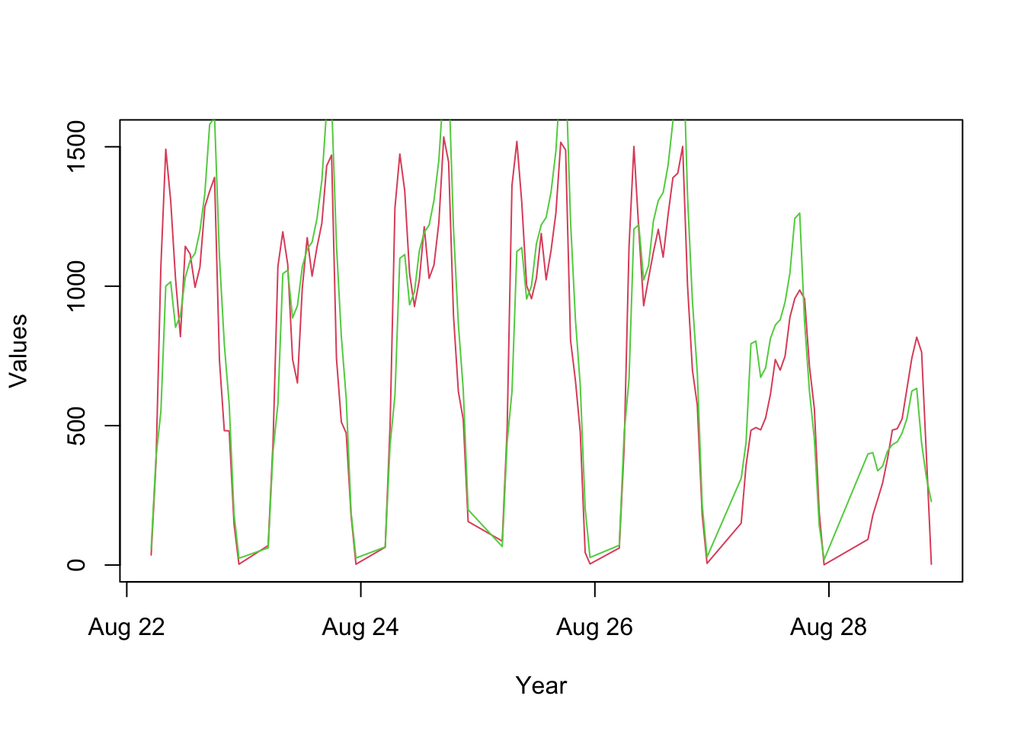

```r
plot(df_test$ds,                              # Draw first time series
     df_test$y,
     type = "l",
     col = 2,
     #ylim = c(- 15, 40),
     xlab = "Year",
     ylab = "Values")
lines(df_test$ds,                             # Draw second time series
      df_test$y_final,
      type = "l",
      col = 3)
```

Calculo RMSE:

```r
require(Metrics)
rmse(df_test$y, df_test$y_final)
```

```
## [1] 224.2078
```

Considerando el error del modelo, se podría incluir alguna interacción entre el horario y el día (o si es fin de semana o no como regresora del modelo) lo que también podría ayduarnos a explicar la estructura que se observa en los residuos del arima.

Se probó también con un SARIMA modelando la estacionalidad de la serie, pero al haber más de un componente estacional en la serie no logra descomponer correctamente el componente estacional del resto. Ese enfoque quedó en la branch: `arima-arma`

### Prophet

A continuación, vamos a modelar el mismo problema utilizando prophet de la misma forma que fue abordado en la clase de la materia:

https://github.com/lhtrevisani/EEA-2022/tree/main/clase%2011

En primer lugar, agregamos los feriados:

```r
# Feriados
feriados = data.frame(
  holiday= 'feriados',
  ds= ymd(c('2022-08-15')),
  lower_window= 0,
  upper_window= 0)
```

Luego, instanciamos el modelo y le pasamos el dataset de entrenamiento.

```r
# Llamamos al modelo con el dataset de eventos
prophet_full=prophet(changepoint.prior.scale=0.01, holidays = feriados)

# Le pasamos el dataset
prophet_full = fit.prophet(m = prophet_full, df_train %>% select(ds, log_y) %>% rename(y = log_y))
```

```
## Disabling yearly seasonality. Run prophet with yearly.seasonality=TRUE to override this.
```

Observamos la descomposición de los distintos componentes de la serie:

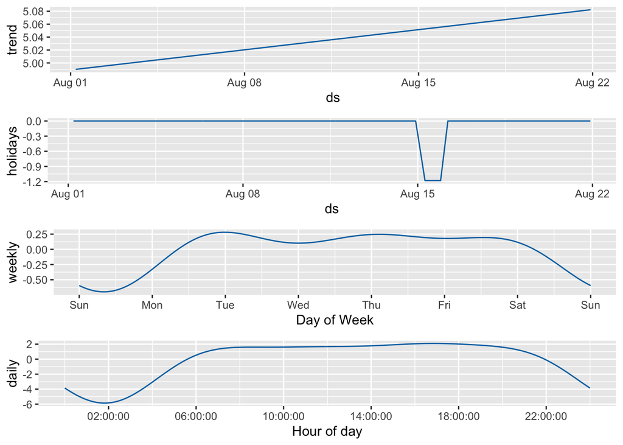

```r
prophet_plot_components(prophet_full, fcst=predict(prophet_full, df_train %>% select(ds, log_y) %>% rename(y = log_y)))
```

Realizamos la predicción sobre la última semana del mes de agosto:

```r
#future <- make_future_dataframe(m, periods = 365)
forecast <- predict(prophet_full, df_test %>% select(ds, log_y) %>% rename(y = log_y))   ## chequear si esto está ok.

resultado = cbind(df_test[c('ds', 'y')], forecast$yhat)
colnames(resultado) <- c("dia", "pasajeros", "log_prediccion")
resultado$prediccion = exp(resultado$log_prediccion)

require(Metrics)
rmse(resultado$pasajeros, resultado$prediccion)
```

```
## [1] 237.3453
```

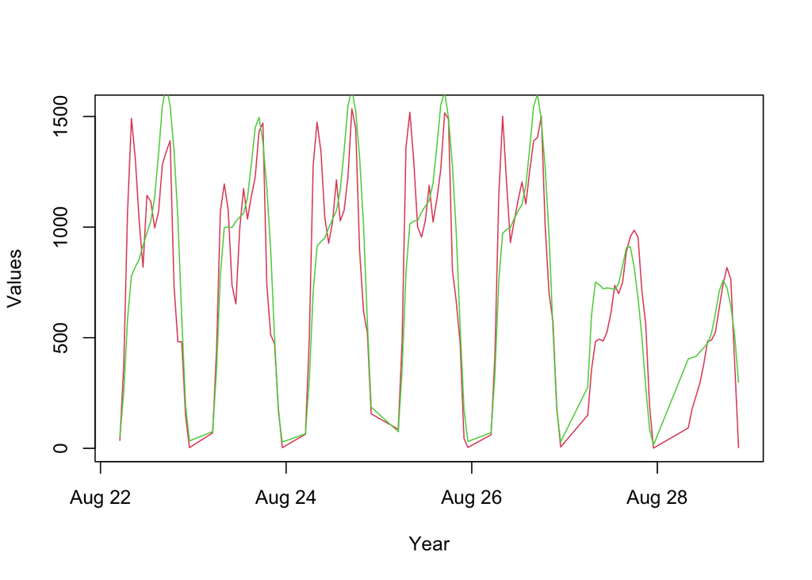

```r
plot(resultado$dia,                              # Draw first time series
     resultado$pasajeros,
     type = "l",
     col = 2,
     #ylim = c(- 15, 40),
     xlab = "Year",
     ylab = "Values")
lines(resultado$dia,                             # Draw second time series
      resultado$prediccion,
      type = "l",
      col = 3)
```

### Algunas conclusiones y resúmen del trabajo:

- El modelo arima desarrollado logró una performance similar a la del modelo generado utilizando prophet. Logra una buena estimación de los pasajeros que recibe la estación Palermo en los distintos horarios y días de la semana, lo que nos podría ayudar, por ejemplo, a medir la cantidad de coches necesarios para trasladar a toda esa masa de gente.
- Sin embargo, el modelo arima no tiene tan resuelto el modelado de cada una de las componentes de la serie temporal, en este análisis se acompañó al arima con una regresión lineal que modela la tendencia y la estacionalidad diaria y horaria de la serie, además de los días feriados. Prophet sí lo logra mucho mejor. La aditividad de los componentes y la posibilidad de modelarlos como una función no lineal del tiempo les permite trabajar mejor con este tipo de series.

### Bibliografía

- Hyndman, R.J., & Athanasopoulos, G. (2021) Forecasting: principles and practice, 3rd edition, OTexts: Melbourne, Australia. OTexts.com/fpp3.
- Shumway, R.H. and Stoffer, D.S. (2011) Time Series Analysis and Its Applications (With R examples), 3rd edition, Springer: New York, USA
- Diebold, F.X. (2008) Elements of forecasting, 4th edition. Mason, Ohio: South-Western/Cengage Learning.
- https://github.com/lhtrevisani/EEA-2022/tree/main/clase%2011